# Overview

The most crucial aspect of any thriving e-commerce business is the skilled management of data. Recognizing this, our project simulates a real-world e-commerce data environment, where our primary goal is to construct a robust database that can not only handle the high volume of transactions characteristic of busy online platforms but also organize data effectively to streamline operations. By recreating a realistic e-commerce scenario, we aim to ensure that businesses remain adaptable, perceptive, and ahead in the fast-paced world of e-commerce.

# Part 1: Database Design and Implementation

## 1.1 E-R Diagram Design

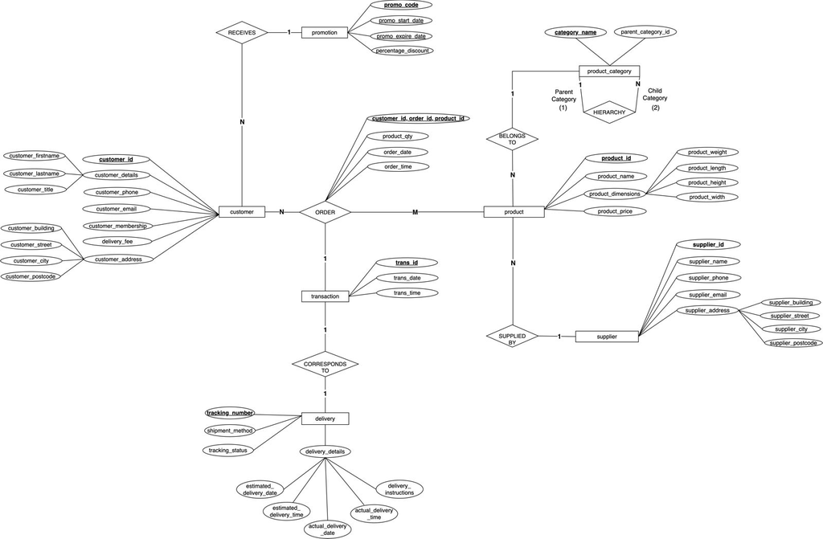

[output not shown]

```r
knitr::include_graphics("ER.jpeg")
```

The architecture of our e-commerce database is structured around seven key entities: customer, product, product category, supplier, promotion, transaction and delivery. These entities are intricately interconnected through a spectrum of relationships, including one-to-one, one-to-many, many-to-many, and self-referencing, in addition to a central ternary relationship.

The “customer” entity, uniquely identified by “customer_id”, holds detailed attributes and forms a many-to-many relationship with “product” entity, signifying that customers can purchase multiple products, and products can be purchased by various customers.

The “product” entity has “product_id” as the primary key and is linked to “product category”. It has a one-to-many relationship where one category can encompass numerous products. Furthermore, “product” is similarly linked with “supplier” entity that is uniquely identified by “supplier_id”. It is connected through a one-to-many relationship, under the assumption that one supplier supplies numerous products.

The “product category” entity has a self-referencing relationship with “category_name” as the primary key. It is a hierarchical category structure with one-to-many relationship, as a single parent category can have multiple child categories, but each child category has only one parent category. For instance, “Beauty” is the parent category, and “Body Wash”, “Perfume” and “Hair Styling Product” are the child categories. Each of these child categories would refer to “Beauty” as their parent, creating a self-referencing relationship.

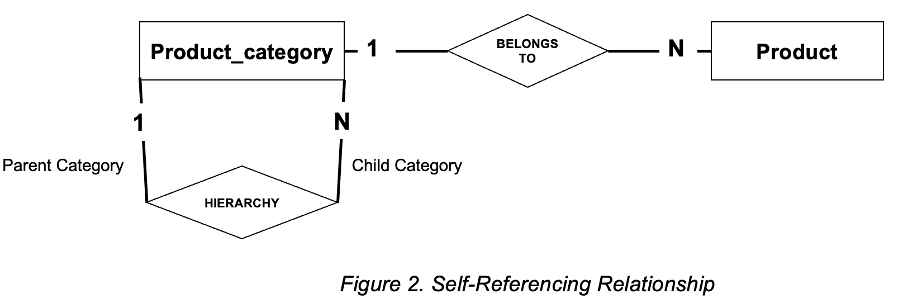

```r
knitr::include_graphics("Self-referencing.png")
```

The “promotion” entity with “promo_code” as the primary key engages in a one-to-many relationship with “Customer” entity, under the assumption that one customer can be associated with one promo code, and many promo code can be associated with multiple customers.

Central to the database, “transaction” captures the financial exchanges and is part of a ternary relationship with “customer” and “product” entities. The three are connected with “order” relationship as is shown below: • A “customer” can have multiple “transaction” (N:1), and within each transaction, multiple “products” can be involved (M:1).

• A “product” can be part of multiple “transaction” through different “customers” (M:N), but within a specific transaction, it is uniquely identified.

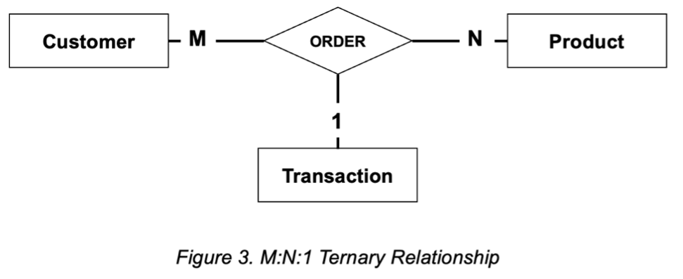

```r
knitr::include_graphics("MN1 Ternary Relationship.png")
```

```r
knitr::include_graphics("Relationship Sets.jpeg")
```

[output not shown]

## Assumptions

To shape our database’s logical structure, we have established several assumptions. First, we assume that our E-commerce business commenced in June 2023. We have a singular supplier relationship where a product is supplied by only one supplier. Each customer and supplier have only one address within the United Kingdom, with every customer and supplier allowed to add only one email address and contact number. Furthermore, our operating procedure presumed that the recipient name for each order corresponds to the name provided by the customer during the ordering process. All product prices are listed in GBP, and a free delivery fee is applied to membership holders. On the contrary, there’s a delivery fee for customers without membership. All deliveries are handled by our own company, and not by an external company. The delivery time is between 7am – 5pm, and each parcel is delivered to each customer’s unique address. All transactions are considered as completed, with no pending or failed statuses, whereas orders placed prior to March 2024 are presumed to be delivered and completed.

## Logical Schema

Upon completion of the ER diagram, we moved to the logical schema phase where each attribute corresponds to a column within that table. Consequently, seven tables are established to represent the seven entities: product_category, promotion, supplier, customer, delivery, product and transaction.

When designing the logical schema, a careful review of entity relationships is crucial to determine any additional tables are required. Relationships with cardinalities of 1:1 or N:1 typically do not require extra tables or changes. However, in N:1 relationships, where multiple instances of one entity are associated with a single instance of another, the primary key from the entity on the “1”- weak side transforms into a foreign key in the table on the “N” – strong side. In our ER diagram, we observe that multiple products belong to one product_category (N:1), and multiple products are supplied by one supplier (N:1). Thus, the primary keys “category_name” and “supplier_id” of the weak side are both transferred to the product table as a foreign key. This is the same case for “promo_code” from the promotion table transferred to the customer table as a foreign key. Below is a list of logical schemas for all entities:

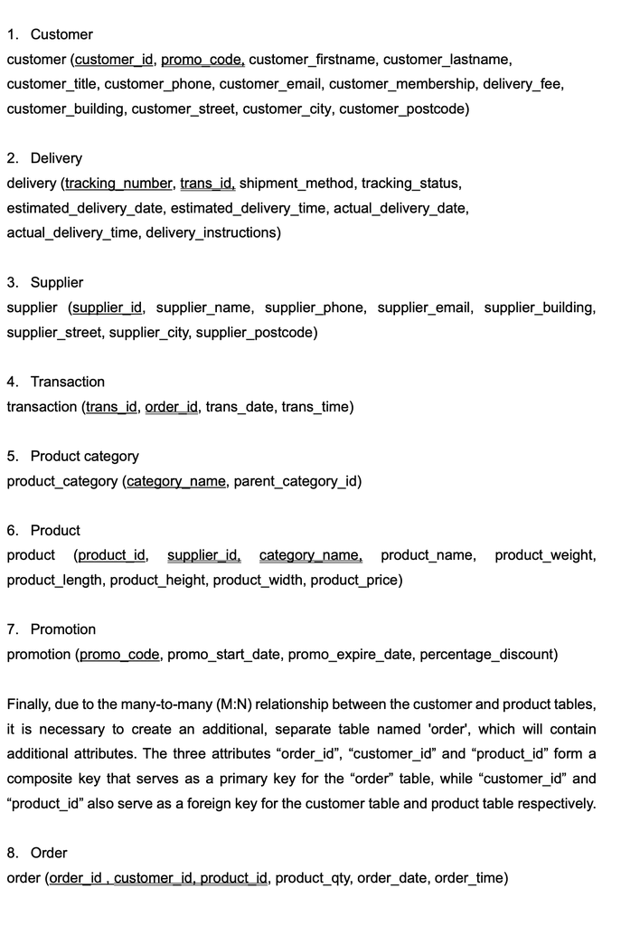

```r
knitr::include_graphics("Logical Schema.png")
```

## Part 1.2: Database Schema Creation

The database schema creation process starts with establishing a connection and creating SQL tables for each entity, proactively dropping any pre-existing tables to avoid potential issues.

# Load Files in an sqlite database

```r
#setup the connection
connection <- RSQLite::dbConnect(RSQLite::SQLite(),"hi_import.db")
```

# Drop tables

```sql
DROP TABLE IF EXISTS product
```

```sql
DROP TABLE IF EXISTS product_category
```

```sql
DROP TABLE IF EXISTS promotion
```

```sql
DROP TABLE IF EXISTS supplier
```

```sql
DROP TABLE IF EXISTS "transaction"
```

```sql
DROP TABLE IF EXISTS order_datetime
```

```sql
DROP TABLE IF EXISTS order_products_info
```

```sql
DROP TABLE IF EXISTS actual_delivery_date
```

```sql
DROP TABLE IF EXISTS delivery_tracking
```

```sql
DROP TABLE IF EXISTS estimated_delivery_date
```

```sql
DROP TABLE IF EXISTS customer_membership
```

```sql
DROP TABLE IF EXISTS customer_basic_info
```

```sql
DROP TABLE IF EXISTS customer
```

```sql
DROP TABLE IF EXISTS delivery
```

```sql
DROP TABLE IF EXISTS "order"
```

# Create SQL tables

## product_category

```sql
-- product_category
CREATE TABLE "product_category" (
  category_name VARCHAR(50) PRIMARY KEY,
  parent_category_id CHAR NULL
);
```

```sql
SELECT * FROM "product_category";
```

0 records

| category_name | parent_category_id |
| --- | --- |

## promotion

```sql
-- promotion
CREATE TABLE "promotion" (
  promo_code INT PRIMARY KEY,
  promo_start_date DATE NULL,
  promo_expire_date DATE NULL,
  percentage_discount NUMERIC NOT NULL
  );
```

```sql
SELECT * FROM "promotion";
```

0 records

| promo_code | promo_start_date | promo_expire_date | percentage_discount |
| --- | --- | --- | --- |

## supplier

```sql
-- supplier
CREATE TABLE supplier (
  supplier_id INT PRIMARY KEY,
  supplier_name CHAR NOT NULL,
  supplier_phone INT NOT NULL,
  supplier_email VARCHAR(50) NOT NULL,
  supplier_building INT NOT NULL,
  supplier_street VARCHAR(50) NOT NULL,
  supplier_city VARCHAR(50) NOT NULL,
  supplier_postcode VARCHAR(50) NOT NULL
) ;
```

```sql
SELECT * FROM "supplier";
```

0 records

| supplier_id | supplier_name | supplier_phone | supplier_email | supplier_building | supplier_street | supplier_city | supplier_postcode |
| --- | --- | --- | --- | --- | --- | --- | --- |

## customer

```sql
-- customer
CREATE TABLE "customer" (
  customer_id INT PRIMARY KEY,
  promo_code INT,
  customer_firstname VARCHAR(50) NOT NULL,
  customer_lastname VARCHAR(50) NOT NULL,
  customer_title VARCHAR(25) NOT NULL,
  customer_phone VARCHAR(50) NOT NULL,
  customer_email VARCHAR(50) NOT NULL,
  customer_membership TEXT NOT NULL,
  delivery_fee NUMERIC NOT NULL,
  customer_building INT NOT NULL,
  customer_street VARCHAR(50) NOT NULL,
  customer_city VARCHAR(50) NOT NULL,
  customer_postcode VARCHAR(50) NOT NULL,
  FOREIGN KEY (promo_code) REFERENCES "promotion"(promo_code)
) ;
```

```sql
SELECT * FROM "customer";
```

0 records

| customer_id | promo_code | customer_firstname | customer_lastname | customer_title | customer_phone | customer_email | customer_membership | delivery_fee | customer_building | customer_street | customer_city | customer_postcode |
| --- | --- | --- | --- | --- | --- | --- | --- | --- | --- | --- | --- | --- |

## delivery

```sql
-- delivery
CREATE TABLE "delivery" (
  tracking_number INT PRIMARY KEY,
  trans_id INT,
  shipment_method VARCHAR(50) NOT NULL,
  tracking_status VARCHAR(50) NOT NULL,
  estimated_delivery_date DATE NOT NULL,
  estimated_delivery_time TIME NOT NULL,
  actual_delivery_date DATE NULL,
  actual_delivery_time TIME NULL,
  delivery_instructions VARCHAR(125) NOT NULL,
  FOREIGN KEY (trans_id) REFERENCES "transaction"(trans_id)
);
```

```sql
SELECT * FROM "delivery";
```

0 records

| tracking_number | trans_id | shipment_method | tracking_status | estimated_delivery_date | estimated_delivery_time | actual_delivery_date | actual_delivery_time | delivery_instructions |
| --- | --- | --- | --- | --- | --- | --- | --- | --- |

## product

```sql
-- product
CREATE TABLE "product" (
  product_id INT PRIMARY KEY,
  supplier_id INT,
  category_name VARCHAR(50),
  product_name VARCHAR(25) NOT NULL,
  product_weight NUMERIC NOT NULL,
  product_length NUMERIC NOT NULL,
  product_height NUMERIC NOT NULL,
  product_width NUMERIC NOT NULL,
  product_price NUMERIC NOT NULL,
  FOREIGN KEY (supplier_id) REFERENCES "supplier"(supplier_id),
  FOREIGN KEY (category_name) REFERENCES "product_category"(category_name)
) ;
```

```sql
SELECT * FROM "product";
```

0 records

| product_id | supplier_id | category_name | product_name | product_weight | product_length | product_height | product_width | product_price |
| --- | --- | --- | --- | --- | --- | --- | --- | --- |

## order

```sql
-- order
CREATE TABLE "order" (
  order_id INT,
  customer_id INT,
  product_id INT,
  product_qty INT NOT NULL,
  order_date DATE NOT NULL,
  order_time TIME NOT NULL,
  PRIMARY KEY (order_id, customer_id, product_id),
  FOREIGN KEY (customer_id) REFERENCES "customer"(customer_id),
  FOREIGN KEY (product_id) REFERENCES "product"(product_id)
) ;
```

```sql
SELECT * FROM "order";
```

0 records

| order_id | customer_id | product_id | product_qty | order_date | order_time |
| --- | --- | --- | --- | --- | --- |

## transaction

```sql
-- transaction
CREATE TABLE "transaction" (
  trans_id INT PRIMARY KEY,
  order_id INT,
  trans_date DATE NOT NULL,
  trans_time TIME NOT NULL,
  FOREIGN KEY (order_id) REFERENCES "order"(order_id)
);
```

```sql
SELECT * FROM "transaction";
```

0 records

| trans_id | order_id | trans_date | trans_time |
| --- | --- | --- | --- |

# Normalization to 3NF

## For customer

1. customer_basic_info

```sql
-- customer_basic_info
CREATE TABLE "customer_basic_info" (
  customer_id INT PRIMARY KEY,
  promo_code INT,
  customer_firstname VARCHAR(50) NOT NULL,
  customer_lastname VARCHAR(50) NOT NULL,
  customer_title VARCHAR(25) NOT NULL,
  customer_phone VARCHAR(50) NOT NULL,
  customer_email VARCHAR(50) NOT NULL,
  customer_building INT NOT NULL,
  customer_street VARCHAR(50) NOT NULL,
  customer_city VARCHAR(50) NOT NULL,
  customer_postcode VARCHAR(50) NOT NULL,
  FOREIGN KEY (promo_code) REFERENCES "promotion"(promo_code)
) ;
```

```sql
SELECT * FROM customer_basic_info
```

0 records

| customer_id | promo_code | customer_firstname | customer_lastname | customer_title | customer_phone | customer_email | customer_building | customer_street | customer_city | customer_postcode |
| --- | --- | --- | --- | --- | --- | --- | --- | --- | --- | --- |

2. customer_membership

```sql
-- customer_membership
CREATE TABLE "customer_membership" (
  customer_id INT,
  customer_membership TEXT,
  delivery_fee NUMERIC NOT NULL,
  PRIMARY KEY (customer_id, customer_membership),
  FOREIGN KEY (customer_id) REFERENCES "customer_basic_info"(customer_id)
);
```

```sql
SELECT * FROM customer_membership
```

0 records

| customer_id | customer_membership | delivery_fee |
| --- | --- | --- |

## For order

1. order_products_info

```sql
-- order_products_info
CREATE TABLE "order_products_info" (
  order_id INT,
  customer_id INT,
  product_id INT,
  product_qty INT NOT NULL,
  PRIMARY KEY (order_id, customer_id, product_id),
  FOREIGN KEY (customer_id) REFERENCES "customer_basic_info"(customer_id),
  FOREIGN KEY (product_id) REFERENCES "product"(product_id)
) ;
```

```sql
SELECT * FROM order_products_info
```

0 records

| order_id | customer_id | product_id | product_qty |
| --- | --- | --- | --- |

2. order_datetime

```sql
-- order_datetime
CREATE TABLE "order_datetime" (
  order_id INT,
  customer_id INT,
  order_date DATE NOT NULL,
  order_time TIME NOT NULL,
  PRIMARY KEY (order_id, customer_id),
  FOREIGN KEY (customer_id) REFERENCES "customer_basic_info"(customer_id)
) ;
```

```sql
SELECT * FROM order_datetime
```

0 records

| order_id | customer_id | order_date | order_time |
| --- | --- | --- | --- |

## For Delivery

1. delivery_tracking

```sql
-- delivery_tracking
CREATE TABLE "delivery_tracking" (
  tracking_number INT PRIMARY KEY,
  trans_id INT,
  delivery_instructions VARCHAR(125) NOT NULL,
  FOREIGN KEY (trans_id) REFERENCES "transaction"(trans_id)
);
```

```sql
SELECT * FROM delivery_tracking
```

0 records

| tracking_number | trans_id | delivery_instructions |
| --- | --- | --- |

2. estimated_delivery_date

```sql
-- estimated_delivery_date
CREATE TABLE "estimated_delivery_date" (
  tracking_number INT,
  shipment_method VARCHAR(50),
  estimated_delivery_date DATE NOT NULL,
  estimated_delivery_time TIME NOT NULL,
  PRIMARY KEY (tracking_number, shipment_method),
  FOREIGN KEY (tracking_number) REFERENCES "delivery_tracking"(tracking_number)
);
```

```sql
SELECT * FROM estimated_delivery_date
```

0 records

| tracking_number | shipment_method | estimated_delivery_date | estimated_delivery_time |
| --- | --- | --- | --- |

3. actual_delivery_date

```sql
-- actual_delivery_date
CREATE TABLE "actual_delivery_date" (
  tracking_number INT,
  tracking_status VARCHAR(50),
  actual_delivery_date DATE NULL,
  actual_delivery_time TIME NULL,
  PRIMARY KEY (tracking_number, tracking_status),
  FOREIGN KEY (tracking_number) REFERENCES "delivery_tracking"(tracking_number)
);
```

```sql
SELECT * FROM actual_delivery_date
```

0 records

| tracking_number | tracking_status | actual_delivery_date | actual_delivery_time |
| --- | --- | --- | --- |

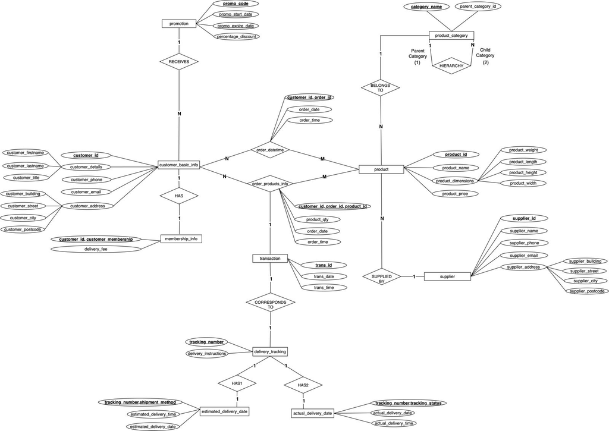

```
                          Figure 5: ER Diagram - After Normalisation
```

```r
knitr::include_graphics("ER after Normalisation.jpeg")
```

# Part 2: Data Generation and Management

## Part 2.1: Synthetic Data Generation

We have initially generated synthetic data using Mockaroo, a random test data generator, and ChatGPT, a generative AI, which we downloaded the data into an excel sheet by updating the field names, data types, and options. However, there are some fields related to date and time which need to be generated with conditions. We use R code to generate these data to ensure the chronological order of date and time for promotion table, order table, transaction table and delivery table.

## Part 2.2: Data Import and Quality Assurance

# Import csv files into SQL table

## For loop to read csv and then import into sql

```r
# Read datasets
#order
order_datetime_dataset <- read.csv("Dataset/hi_order_datetime_dataset.csv")
order_products_info_dataset <- read.csv("Dataset/hi_order_products_info_dataset.csv")

#delivery

actual_delivery_date_dataset <- read.csv("Dataset/hi_actual_delivery_date_dataset.csv")
delivery_tracking_dataset <- read.csv("Dataset/hi_delivery_tracking_dataset.csv")
estimated_delivery_date_dataset <- read.csv("Dataset/hi_estimated_delivery_date_dataset.csv")

#customer
customer_basic_info_dataset <- read.csv("Dataset/hi_customer_basic_info_dataset.csv")
customer_membership_dataset <- read.csv("Dataset/hi_customer_membership_dataset.csv")
product_dataset <- read.csv("Dataset/hi_product_dataset.csv")
product_category_dataset <- read.csv("Dataset/hi_product_category_dataset.csv")
promotion_dataset <- read.csv("Dataset/hi_promotion_dataset.csv")
supplier_dataset <- read.csv("Dataset/hi_supplier_dataset.csv")
transaction_dataset <- read.csv("Dataset/hi_transaction_dataset.csv")
```

```r
dbWriteTable(connection, "product", product_dataset, append = TRUE, row.names = FALSE)
dbWriteTable(connection, "product_category", product_category_dataset, append = TRUE, row.names = FALSE)
dbWriteTable(connection, "promotion", promotion_dataset, append = TRUE, row.names = FALSE)
dbWriteTable(connection, "supplier", supplier_dataset, append = TRUE, row.names = FALSE)
dbWriteTable(connection, "transaction", transaction_dataset, append = TRUE, row.names = FALSE)

#order
dbWriteTable(connection, "order_datetime", order_datetime_dataset, append = TRUE, row.names = FALSE)
dbWriteTable(connection, "order_products_info", order_products_info_dataset, append = TRUE, row.names = FALSE)

#delivery
dbWriteTable(connection, "actual_delivery_date", actual_delivery_date_dataset, append = TRUE, row.names = FALSE)
dbWriteTable(connection, "delivery_tracking", delivery_tracking_dataset, append = TRUE, row.names = FALSE)
dbWriteTable(connection, "estimated_delivery_date", estimated_delivery_date_dataset, append = TRUE, row.names = FALSE)

#customer
dbWriteTable(connection, "customer_membership", customer_membership_dataset, append = TRUE, row.names = FALSE)
dbWriteTable(connection, "customer_basic_info", customer_basic_info_dataset, append = TRUE, row.names = FALSE)
```

## Check the tables using select

```sql
SELECT * FROM "product" LIMIT 5
```

5 records

| product_id | supplier_id | category_name | product_name | product_weight | product_length | product_height | product_width | product_price |
| --- | --- | --- | --- | --- | --- | --- | --- | --- |
| 34-100-2931 | RSH-48812 | Biography | Unveiled: The Life of a Visionary | 4322 | 67 | 35 | 30 | 11.62 |
| 60-215-8627 | HNW-87364 | Educational Toys | Learn & Play Alphabet Blocks | 614 | 24 | 22 | 98 | 30.83 |
| 10-395-8862 | QIS-31117 | Fresh Produce | Organic Harvest Bundle | 1942 | 65 | 10 | 30 | 26.30 |
| 84-465-9981 | TJZ-16253 | History | Epochs in Time: A Historical Analysis | 3825 | 74 | 73 | 47 | 43.25 |
| 51-355-5771 | OTM-80847 | Mystery | Whispers in the Shadows: Mystery Novel | 471 | 67 | 31 | 87 | 14.78 |

```sql
SELECT * FROM "product_category" LIMIT 5
```

5 records

| category_name | parent_category_id |
| --- | --- |
| Beauty |  |
| Books |  |
| Clothing |  |
| Electronics |  |
| Grocery |  |

```sql
SELECT * FROM "promotion" LIMIT 5
```

5 records

| promo_code | promo_start_date | promo_expire_date | percentage_discount |
| --- | --- | --- | --- |
| BU86M505PYD | 07/07/2023 | 27/12/2023 | 50 |
| BG70Z584RFB | 09/11/2023 | 03/03/2024 | 25 |
| JI24S173EUJ | 20/03/2024 | 07/07/2024 | 45 |
| FU87P552XKO | 24/11/2023 | 06/04/2024 | 45 |
| SD70E981QNT | 16/02/2024 | 04/08/2024 | 40 |

```sql
SELECT * FROM "supplier" LIMIT 5
```

5 records

| supplier_id | supplier_name | supplier_phone | supplier_email | supplier_building | supplier_street | supplier_city | supplier_postcode |
| --- | --- | --- | --- | --- | --- | --- | --- |
| XTE-60952 | Hyatt and Sons | +44 336 825 7695 | mkilpatrick0@nyu.edu | 796 | Garden Road | London | KY2Y 6JZ |
| WLS-09227 | Huels-Krajcik | +44 515 420 8651 | cbritt1@unesco.org | 881 | Meadow Road | Birmingham | B12 7TB |
| RCO-72629 | Morissette LLC | +44 213 964 1394 | ctrussler2@hao123.com | 66 | Garden Road | Birmingham | DE9W 6WF |
| KCV-52154 | Koepp, Bechtelar and Weimann | +44 404 383 6574 | egoddman3@mtv.com | 921 | River Road | London | W1 9SG |
| UTZ-90791 | Stamm-Schmidt | +44 312 442 5804 | lharome4@oaic.gov.au | 254 | Lake Road | Bristol | L43 3FX |

```sql
SELECT * FROM "transaction" LIMIT 5
```

5 records

| trans_id | order_id | trans_date | trans_time |
| --- | --- | --- | --- |
| EHD-784624 | AAD-4091 | 10/11/2023 | 07:56:40 |
| SIZ-926836 | AAK-0526 | 09/02/2024 | 15:23:52 |
| GEP-276863 | ADJ-6838 | 02/08/2023 | 12:30:16 |
| YRS-371629 | ADV-4775 | 26/10/2023 | 14:57:31 |
| VMS-478374 | ADX-1928 | 28/02/2024 | 00:15:39 |

Order:

```sql
SELECT * FROM "order_datetime" LIMIT 5
```

5 records

| order_id | customer_id | order_date | order_time |
| --- | --- | --- | --- |
| AAD-4091 | YTS-92438 | 10/11/2023 | 05:43:29 |
| AAK-0526 | BWU-36083 | 09/02/2024 | 14:20:43 |
| AAK-6361 | CLZ-73501 | 28/03/2024 | 20:29:45 |
| ADJ-5614 | KCQ-71974 | 19/11/2023 | 23:34:47 |
| ADJ-6838 | GSB-19226 | 02/08/2023 | 11:28:04 |

```sql
SELECT * FROM "order_products_info" LIMIT 5
```

5 records

| order_id | customer_id | product_id | product_qty |
| --- | --- | --- | --- |
| AAD-4091 | YTS-92438 | 42-811-3974 | 9 |
| AAD-4091 | YTS-92438 | 72-217-8555 | 10 |
| AAK-0526 | BWU-36083 | 85-279-1314 | 5 |
| AAK-0526 | BWU-36083 | 43-612-9451 | 19 |
| AAK-0526 | BWU-36083 | 42-665-9904 | 16 |

Delivery

```sql
SELECT * FROM "actual_delivery_date" LIMIT 5
```

5 records

| tracking_number | tracking_status | actual_delivery_date | actual_delivery_time |
| --- | --- | --- | --- |
| 581-6200 | Delivered | 24/06/2023 | 12:45:44 |
| 004-1482 | Delivered | 22/11/2023 | 08:18:48 |
| 064-9023 | In process | NA | NA |
| 657-4120 | Delivered | 01/02/2024 | 07:43:05 |
| 983-4613 | Delivered | 12/08/2023 | 11:01:41 |

```sql
SELECT * FROM "delivery_tracking" LIMIT 5
```

5 records

| tracking_number | trans_id | delivery_instructions |
| --- | --- | --- |
| 581-6200 | AAA-067232 | ring bell |
| 004-1482 | AAC-152328 | delivery box |
| 064-9023 | AAD-850184 | ring bell |
| 657-4120 | AAR-680860 | leave infront of door |
| 983-4613 | AAT-296188 | ring bell |

```sql
SELECT * FROM "estimated_delivery_date" LIMIT 5
```

5 records

| tracking_number | shipment_method | estimated_delivery_date | estimated_delivery_time |
| --- | --- | --- | --- |
| 581-6200 | express | 23/06/2023 | 11:20:33 |
| 004-1482 | next day | 21/11/2023 | 14:41:18 |
| 064-9023 | express | 06/03/2024 | 07:27:46 |
| 657-4120 | standard | 01/02/2024 | 15:10:18 |
| 983-4613 | next day | 11/08/2023 | 16:02:04 |

Customer:

```sql
SELECT * FROM "customer_membership" LIMIT 5
```

5 records

| customer_id | customer_membership | delivery_fee |
| --- | --- | --- |
| NAT-21446 | membership | 0.00 |
| MQV-12400 | not membership | 4.99 |
| MLY-44705 | not membership | 5.99 |
| RFE-59474 | membership | 0.00 |
| WBO-40739 | membership | 0.00 |

```sql
SELECT * FROM "customer_basic_info" LIMIT 5
```

5 records

| customer_id | promo_code | customer_firstname | customer_lastname | customer_title | customer_phone | customer_email | customer_building | customer_street | customer_city | customer_postcode |
| --- | --- | --- | --- | --- | --- | --- | --- | --- | --- | --- |
| NAT-21446 | VS04A935ONO | Mike | Berriball | Dr | +44 482 422 6609 | mberriball0@abc.net.au | 103 | Willow Street | Birmingham | B1D 6RT |
| MQV-12400 | OQ50R170HWT | Antone | Lujan | Mr | +44 941 356 9889 | alujan1@qq.com | 436 | Spruce Street | Birmingham | G1A 8DD |
| MLY-44705 | DU63L727XKV | Moria | Llewellen | Honorable | +44 398 412 8484 | mllewellen2@hud.gov | 861 | Willow Street | Bristol | G4H 0NH |
| RFE-59474 | IW96D852NGT | Ichabod | Philson | Honorable | +44 114 708 3717 | iphilson3@github.com | 271 | Maple Street | Bristol | M04 5UF |
| WBO-40739 | IX31K072LEZ | Leena | Strangeway | Mrs | +44 782 865 8414 | lstrangeway4@utexas.edu | 107 | Ash Street | Birmingham | M8 3LL |

# Calculated Field

## Transaction amount

```sql
SELECT o.order_id, prm.percentage_discount, m.delivery_fee, SUM(p.product_price*o.product_qty) AS order_price, ROUND(SUM(p.product_price* o.product_qty)*(1 - CAST(prm.percentage_discount AS REAL) / 100) + m.delivery_fee,2) AS trans_amount
FROM "order_products_info" o, "product" p, "promotion" prm, "customer_basic_info" c, "customer_membership" m
WHERE o.customer_id = m.customer_id AND o.product_id = p.product_id AND c.promo_code = prm.promo_code AND m.customer_id = c.customer_id
GROUP BY
    o.order_id;
```

Displaying records 1 - 10

| order_id | percentage_discount | delivery_fee | order_price | trans_amount |
| --- | --- | --- | --- | --- |
| AAD-4091 | 25 | 0.00 | 822.15 | 616.61 |
| AAK-0526 | 30 | 0.00 | 767.93 | 537.55 |
| AAK-6361 | 25 | 6.99 | 1058.78 | 801.08 |
| ADJ-5614 | 45 | 3.99 | 193.16 | 110.23 |
| ADJ-6838 | 35 | 2.99 | 681.37 | 445.88 |
| ADV-4775 | 45 | 5.99 | 1113.84 | 618.60 |
| ADV-7947 | 20 | 5.99 | 116.87 | 99.49 |
| ADX-1928 | 45 | 0.00 | 892.56 | 490.91 |
| ADX-2356 | 40 | 0.00 | 350.07 | 210.04 |
| AFD-0715 | 15 | 0.00 | 827.32 | 703.22 |

# Store natively it in R

```r
# Customer
customer_membership <- dbReadTable(connection, "customer_membership")
customer_basic_info <- dbReadTable(connection, "customer_basic_info")

#Delivery
actual_delivery_date <- dbReadTable(connection, "actual_delivery_date")
delivery_tracking <- dbReadTable(connection, "delivery_tracking")
estimated_delivery_date <- dbReadTable(connection, "estimated_delivery_date")

#Order
order_datetime <- dbReadTable(connection, "order_datetime")
order_products_info <- dbReadTable(connection, "order_products_info")

product <- dbReadTable(connection, "product")
product_category <- dbReadTable(connection, "product_category")
promotion <- dbReadTable(connection, "promotion")
supplier <- dbReadTable(connection, "supplier")
transaction <- dbReadTable(connection, "transaction")
```

# List tables

```r
RSQLite::dbListTables(connection)
```

```
##  [1] "actual_delivery_date"    "customer"
##  [3] "customer_basic_info"     "customer_membership"
##  [5] "customer_memebership"    "delivery"
##  [7] "delivery_tracking"       "estimated_delivery_date"
##  [9] "order"                   "order_datetime"
## [11] "order_products_info"     "product"
## [13] "product_category"        "promotion"
## [15] "supplier"                "transaction"
```

# Disconnect SQL

```r
RSQLite::dbDisconnect(connection)
```

# List all files

```r
all_files <- list.files("Dataset/")
all_files
```

```
##  [1] "hi_actual_delivery_date_dataset.csv"
##  [2] "hi_customer_basic_info_dataset.csv"
##  [3] "hi_customer_membership_dataset.csv"
##  [4] "hi_delivery_tracking_dataset.csv"
##  [5] "hi_estimated_delivery_date_dataset.csv"
##  [6] "hi_order_datetime_dataset.csv"
##  [7] "hi_order_products_info_dataset.csv"
##  [8] "hi_product_category_dataset.csv"
##  [9] "hi_product_dataset.csv"
## [10] "hi_promotion_dataset.csv"
## [11] "hi_supplier_dataset.csv"
## [12] "hi_transaction_dataset.csv"
```

```r
prefix <- "hi_"
suffix <- "_dataset.csv"
all_files <- gsub("hi_","",all_files)
all_files <- gsub("_dataset.csv","",all_files)
all_files
```

```
##  [1] "actual_delivery_date"    "customer_basic_info"
##  [3] "customer_membership"     "delivery_tracking"
##  [5] "estimated_delivery_date" "order_datetime"
##  [7] "order_products_info"     "product_category"
##  [9] "product"                 "promotion"
## [11] "supplier"                "transaction"
```

In our pursuit of ensuring data integrity, we implemented a comprehensive quality assurance process which included:

## Check number of rows and columns

```r
all_files <- list.files("Dataset/")

for (variable in all_files) {
  this_filepath <- paste0("Dataset/",variable)
  this_file_contents <- readr::read_csv(this_filepath)

  number_of_rows <- nrow(this_file_contents)
  number_of_columns <- ncol(this_file_contents)

  print(paste0("The file: ",variable,
              " has: ",
              format(number_of_rows,big.mark = ","),
              " rows and ",
              number_of_columns," columns"))
}
```

```
## [1] "The file: hi_actual_delivery_date_dataset.csv has: 1,000 rows and 4 columns"
## [1] "The file: hi_customer_basic_info_dataset.csv has: 1,000 rows and 11 columns"
## [1] "The file: hi_customer_membership_dataset.csv has: 1,000 rows and 3 columns"
## [1] "The file: hi_delivery_tracking_dataset.csv has: 1,000 rows and 3 columns"
## [1] "The file: hi_estimated_delivery_date_dataset.csv has: 1,000 rows and 4 columns"
## [1] "The file: hi_order_datetime_dataset.csv has: 1,681 rows and 4 columns"
## [1] "The file: hi_order_products_info_dataset.csv has: 3,401 rows and 4 columns"
## [1] "The file: hi_product_category_dataset.csv has: 88 rows and 2 columns"
## [1] "The file: hi_product_dataset.csv has: 1,000 rows and 9 columns"
## [1] "The file: hi_promotion_dataset.csv has: 1,000 rows and 4 columns"
## [1] "The file: hi_supplier_dataset.csv has: 1,000 rows and 8 columns"
## [1] "The file: hi_transaction_dataset.csv has: 1,000 rows and 4 columns"
```

## Check the data structure

```r
all_files <- list.files("Dataset/")

for (variable in all_files) {
  this_filepath <- paste0("Dataset/",variable)
  this_file_contents <- readr::read_csv(this_filepath)
  data_structure<-str(this_file_contents)

  print(paste0(data_structure,
               "The file: ",variable,
              " has above data structure"))
}
```

```
## spc_tbl_ [1,000 × 4] (S3: spec_tbl_df/tbl_df/tbl/data.frame)
##  $ tracking_number     : chr [1:1000] "581-6200" "004-1482" "064-9023" "657-4120" ...
##  $ tracking_status     : chr [1:1000] "Delivered" "Delivered" "In process" "Delivered" ...
##  $ actual_delivery_date: chr [1:1000] "24/06/2023" "22/11/2023" NA "01/02/2024" ...
##  $ actual_delivery_time: 'hms' num [1:1000] 12:45:44 08:18:48 NA 07:43:05 ...
##   ..- attr(*, "units")= chr "secs"
##  - attr(*, "spec")=
##   .. cols(
##   ..   tracking_number = col_character(),
##   ..   tracking_status = col_character(),
##   ..   actual_delivery_date = col_character(),
##   ..   actual_delivery_time = col_time(format = "")
##   .. )
##  - attr(*, "problems")=<externalptr>
## [1] "The file: hi_actual_delivery_date_dataset.csv has above data structure"
## spc_tbl_ [1,000 × 11] (S3: spec_tbl_df/tbl_df/tbl/data.frame)
##  $ customer_id       : chr [1:1000] "NAT-21446" "MQV-12400" "MLY-44705" "RFE-59474" ...
##  $ customer_firstname: chr [1:1000] "Mike" "Antone" "Moria" "Ichabod" ...
##  $ customer_lastname : chr [1:1000] "Berriball" "Lujan" "Llewellen" "Philson" ...
##  $ customer_title    : chr [1:1000] "Dr" "Mr" "Honorable" "Honorable" ...
##  $ customer_phone    : chr [1:1000] "+44 482 422 6609" "+44 941 356 9889" "+44 398 412 8484" "+44 114 708 3717" ...
##  $ customer_email    : chr [1:1000] "mberriball0@abc.net.au" "alujan1@qq.com" "mllewellen2@hud.gov" "iphilson3@github.com" ...
##  $ customer_building : num [1:1000] 103 436 861 271 107 72 701 21 615 122 ...
##  $ customer_street   : chr [1:1000] "Willow Street" "Spruce Street" "Willow Street" "Maple Street" ...
##  $ customer_city     : chr [1:1000] "Birmingham" "Birmingham" "Bristol" "Bristol" ...
##  $ customer_postcode : chr [1:1000] "B1D 6RT" "G1A 8DD" "G4H 0NH" "M04 5UF" ...
##  $ promo_code        : chr [1:1000] "VS04A935ONO" "OQ50R170HWT" "DU63L727XKV" "IW96D852NGT" ...
##  - attr(*, "spec")=
##   .. cols(
##   ..   customer_id = col_character(),
##   ..   customer_firstname = col_character(),
##   ..   customer_lastname = col_character(),
##   ..   customer_title = col_character(),
##   ..   customer_phone = col_character(),
##   ..   customer_email = col_character(),
##   ..   customer_building = col_double(),
##   ..   customer_street = col_character(),
##   ..   customer_city = col_character(),
##   ..   customer_postcode = col_character(),
##   ..   promo_code = col_character()
```

[output cut: 141 more lines]

```
## spc_tbl_ [1,000 × 4] (S3: spec_tbl_df/tbl_df/tbl/data.frame)
##  $ trans_id  : chr [1:1000] "EHD-784624" "SIZ-926836" "GEP-276863" "YRS-371629" ...
##  $ order_id  : chr [1:1000] "AAD-4091" "AAK-0526" "ADJ-6838" "ADV-4775" ...
##  $ trans_date: chr [1:1000] "10/11/2023" "09/02/2024" "02/08/2023" "26/10/2023" ...
##  $ trans_time: 'hms' num [1:1000] 07:56:40 15:23:52 12:30:16 14:57:31 ...
##   ..- attr(*, "units")= chr "secs"
##  - attr(*, "spec")=
##   .. cols(
##   ..   trans_id = col_character(),
##   ..   order_id = col_character(),
##   ..   trans_date = col_character(),
##   ..   trans_time = col_time(format = "")
##   .. )
##  - attr(*, "problems")=<externalptr>
## [1] "The file: hi_transaction_dataset.csv has above data structure"
```

## Check for NULL values

```r
all_files <- list.files("Dataset/")

for (variable in all_files) {
  this_filepath <- paste0("Dataset/",variable)
  this_file_contents <- readr::read_csv(this_filepath)
  null<-sum(is.na(this_file_contents))

  print(paste0("The file: ",variable,
              " has a total of ", null,
              " NULL values"))
}
```

```
## [1] "The file: hi_actual_delivery_date_dataset.csv has a total of 172 NULL values"
## [1] "The file: hi_customer_basic_info_dataset.csv has a total of 0 NULL values"
## [1] "The file: hi_customer_membership_dataset.csv has a total of 0 NULL values"
## [1] "The file: hi_delivery_tracking_dataset.csv has a total of 0 NULL values"
## [1] "The file: hi_estimated_delivery_date_dataset.csv has a total of 0 NULL values"
## [1] "The file: hi_order_datetime_dataset.csv has a total of 0 NULL values"
## [1] "The file: hi_order_products_info_dataset.csv has a total of 0 NULL values"
## [1] "The file: hi_product_category_dataset.csv has a total of 8 NULL values"
## [1] "The file: hi_product_dataset.csv has a total of 0 NULL values"
## [1] "The file: hi_promotion_dataset.csv has a total of 0 NULL values"
## [1] "The file: hi_supplier_dataset.csv has a total of 0 NULL values"
## [1] "The file: hi_transaction_dataset.csv has a total of 0 NULL values"
```

## Check that each primary key is unique in each table except for order

```r
all_files <- list.files("Dataset/")

for (variable in all_files) {
  this_filepath <- paste0("Dataset/",variable)
  this_file_contents <- readr::read_csv(this_filepath)
  hi <- nrow(unique(this_file_contents[,1]))== nrow(this_file_contents)

  print(paste0("The file: ",variable,
              " has unique primary key ",
              hi," columns"))
}
```

```
## [1] "The file: hi_actual_delivery_date_dataset.csv has unique primary key TRUE columns"
## [1] "The file: hi_customer_basic_info_dataset.csv has unique primary key TRUE columns"
## [1] "The file: hi_customer_membership_dataset.csv has unique primary key TRUE columns"
## [1] "The file: hi_delivery_tracking_dataset.csv has unique primary key TRUE columns"
## [1] "The file: hi_estimated_delivery_date_dataset.csv has unique primary key TRUE columns"
## [1] "The file: hi_order_datetime_dataset.csv has unique primary key FALSE columns"
## [1] "The file: hi_order_products_info_dataset.csv has unique primary key FALSE columns"
## [1] "The file: hi_product_category_dataset.csv has unique primary key TRUE columns"
## [1] "The file: hi_product_dataset.csv has unique primary key TRUE columns"
## [1] "The file: hi_promotion_dataset.csv has unique primary key TRUE columns"
## [1] "The file: hi_supplier_dataset.csv has unique primary key TRUE columns"
## [1] "The file: hi_transaction_dataset.csv has unique primary key TRUE columns"
```

## For order dataset

We have a composite primary key orderdate_dataset composed of 2 attribute and a composite primary key orderproductsinfo_dataset composed of 3 attribute, we’ll check these one separately.

```r
orderdate_dataset <- read.csv("Dataset/hi_order_datetime_dataset.csv")
orderproductsinfo_dataset <- read.csv("Dataset/hi_order_products_info_dataset.csv")
nrow(unique(orderdate_dataset[,1:2])) == nrow(orderdate_dataset)
```

```
## [1] TRUE
```

```r
nrow(unique(orderproductsinfo_dataset[,1:3])) == nrow(orderproductsinfo_dataset)
```

```
## [1] TRUE
```

```r
#sum(nrow(unique(orders[,1:2])))
#length((unique(orders$cutomer_id)))
#length((unique(orders$order_id)))
#The file: hi_order_dataset.csv has unique primary composite key TRUE columns
```

In Customer dataset, there are e-mail and phone number columns, which required specific format checks. For e-mail, special characters “@” and ending domain must be validated. For phone number, IT must be ensured to have 10 numeric characters.

## Validate phone number

```r
# Supplier
length(grepl("\\+44\\s\\d{3}\\s\\d{3}\\s\\d{4}", supplier$supplier_phone)) == nrow(supplier)
```

```
## [1] TRUE
```

```r
# Consumer
length(grepl("\\+44\\s\\d{3}\\s\\d{3}\\s\\d{4}", customer_basic_info$customer_phone)) == nrow(customer_basic_info)
```

```
## [1] TRUE
```

## Validate emails

```r
# Supplier
length(grepl("@", supplier$supplier_email)) == nrow(supplier)
```

```
## [1] TRUE
```

```r
# Consumer
length(grepl("@", customer_basic_info$customer_email)) == nrow(customer_basic_info)
```

```
## [1] TRUE
```

# Part 3: Data Pipeline Generation

## Part 3.1: GitHub Repository and Workflow Setup

Our primary objective was to utilize GitHub repositories for efficient version control of our project. Initially, we transformed our R Markdown file into an R script, encompassing all the steps outlined in section 2.2. We proceeded to load the requisite files into a SQLite database, creating tables and importing datasets from the “Dataset” file. Despite solely utilizing the R script, we ensured all pertinent files were maintained within the repository. This was achieved by leveraging the repository’s URL and executing commits and pushes whenever modifications were made. Subsequently, we established a new repository on GitHub and extended invitations to collaborators, granting them appropriate access levels.

## Part 3.2: GitHub Actions for Continuous Integration

For the implementation of GitHub Actions for Continuous Integration, we aimed to streamline our project’s development workflow. This involved adopting continuous integration practices to automate tasks such as data validation, database updates, and data analysis. For instance, whenever changes occurred in the repository, such as importing new data, the updates were seamlessly integrated into the database, and relevant outputs were generated only if significant changes were detected. Scheduled workflows were set to run at regular intervals, such as every three hours, ensuring consistent and efficient execution of these tasks.

Within workflow, we configured the R environment and cached any necessary R packages that were not already installed. Essential packages such as “ggplot” and “dplyr” were installed for data visualization purposes. The workflow then executed the R script, incorporating any changes made during the process. Finally, all modifications were committed to the local repository and subsequently pushed to the main branch using a unique access token for authentication. This comprehensive approach to CI enabled seamless integration of updates and ensured the project’s integrity and efficiency.